# Öğrenci Bilgileri

## Ad ve Soyad

- Ad: [ESRA]
- Soyad: [BEKE]

## Öğrenci Numarası

- Öğrenci Numarası: [23040301014]

## Ders Bilgileri

- Dersin Adı: [Veri.Madenciliği]
- Dersin Kodu: [FET308]

## Bölüm

- Bölüm: [YAZILIM.MÜHENDİSLİĞİ]

## Fakülte

- Fakülte: [MÜHENDİSLİK.FAKÜLTESİ]

## Üniversite

- Üniversite: [İSTANBUL.TOPKAPI.ÜNİVERSİTESİ]

# Dataset Bilgileri

## Grup

- Grup: [E]

## Dataset Adı

- Dataset Adı: [Car.Sales.Data]

## Dataset Linki

- Dataset Linki: [[Datasetin Linki](https://www.kaggle.com/datasets/suraj520/car-sales-data)]

## Dataset Tanımı

Car Sales Data dataset'i, araç satışlarıyla ilgili verileri içermektedir. Bu dataset, araç satışlarının fiyatlarını, markalarını, modellerini, satış tarihlerini ve diğer önemli faktörleri içeren verilerle satış trendlerini analiz etmeyi amaçlamaktadır.

## İçerik

Bu dataset, aşağıdaki sütunları içermektedir:

- **Car Make**: Araç markası
- **Car Model**: Araç modeli
- **Sale Price**: Satış fiyatı
- **Sale Date**: Satış tarihi
- **Commission Earned**: Satış komisyonu

## Kullanım Amacı

Bu veri, araç satışlarının zaman içindeki değişimini analiz etmek ve satış fiyatları ile diğer değişkenler arasındaki ilişkileri incelemek için kullanılabilir. Ayrıca, satış temsilcilerinin komisyon kazançlarıyla satış performanslarını karşılaştırmak için de kullanılabilir.

```python
import pandas as pd
import seaborn as sns
import matplotlib.pyplot as plt
from scipy.stats import norm
import numpy as np
```

```python
file_path = 'C:/Users/esrab/OneDrive/Masaüstü/pythondeneme/car_sales_data.csv'
data = pd.read_csv(file_path)
```

```python
# Veri setine genel bir bakış
data_info = {
    "Satır Sayısı": data.shape[0],
    "Sütun Sayısı": data.shape[1],
    "Sütunlar": data.columns.tolist(),
    "Sütunlar ve Veri Türleri": data.dtypes.to_dict()

}

data_info
```

```
{'Satır Sayısı': 2500000,
 'Sütun Sayısı': 9,
 'Sütunlar': ['Date',
  'Salesperson',
  'Customer Name',
  'Car Make',
  'Car Model',
  'Car Year',
  'Sale Price',
  'Commission Rate',
  'Commission Earned'],
 'Sütunlar ve Veri Türleri': {'Date': dtype('O'),
  'Salesperson': dtype('O'),
  'Customer Name': dtype('O'),
  'Car Make': dtype('O'),
  'Car Model': dtype('O'),
  'Car Year': dtype('int64'),
  'Sale Price': dtype('int64'),
  'Commission Rate': dtype('float64'),
  'Commission Earned': dtype('float64')}}
```

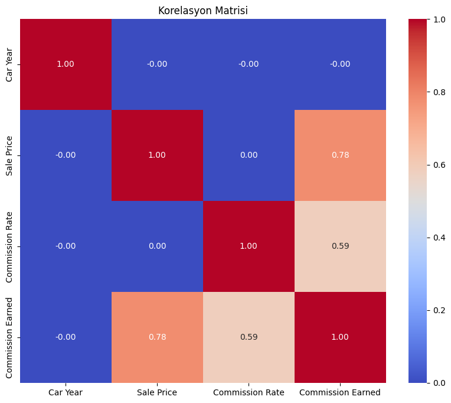

```python
numeric_columns = data.select_dtypes(include=['float64', 'int64']).columns
# Korelasyon matrisini hesaplama
correlation_matrix = data[numeric_columns].corr()


plt.figure(figsize=(10, 8))
sns.heatmap(correlation_matrix, annot=True, cmap="coolwarm", fmt=".2f")
plt.title("Korelasyon Matrisi")
plt.show()
```

```python
# Temel istatistiksel verileri hesaplama
basic_statistics = data.describe()
basic_statistics
```

|  | Car Year | Sale Price | Commission Rate | Commission Earned |
| --- | --- | --- | --- | --- |
| count | 2.500000e+06 | 2.500000e+06 | 2.500000e+06 | 2.500000e+06 |
| mean | 2.015996e+03 | 3.001218e+04 | 9.998766e-02 | 3.001005e+03 |
| std | 3.739132e+00 | 1.154514e+04 | 2.887202e-02 | 1.481467e+03 |
| min | 2.010000e+03 | 1.000000e+04 | 5.000014e-02 | 5.013400e+02 |
| 25% | 2.013000e+03 | 2.001900e+04 | 7.496450e-02 | 1.821710e+03 |
| 50% | 2.016000e+03 | 3.000600e+04 | 1.000058e-01 | 2.741910e+03 |
| 75% | 2.019000e+03 | 4.002200e+04 | 1.250065e-01 | 3.978142e+03 |
| max | 2.022000e+03 | 5.000000e+04 | 1.500000e-01 | 7.494530e+03 |

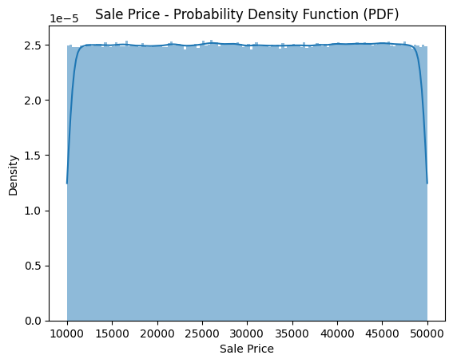

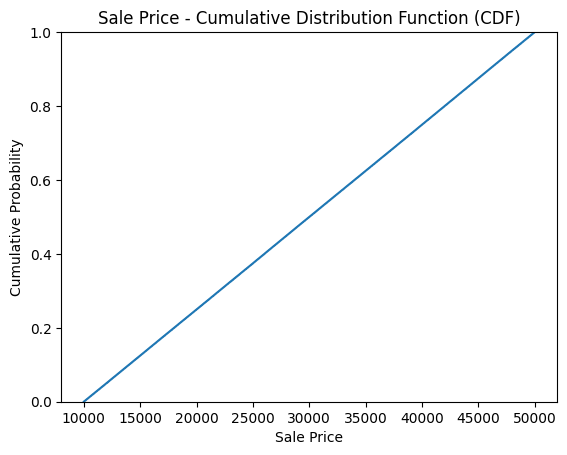

```
Veri aralığındaki (15000 - 30000) olasılık: 0.3751
```

```python
feature = 'Sale Price'

# PDF hesaplama
sns.histplot(data[feature], kde=True, stat="density", linewidth=0)
plt.title(f'{feature} - Probability Density Function (PDF)')
plt.xlabel(feature)
plt.ylabel('Density')
plt.show()

# CDF hesaplama
sns.ecdfplot(data[feature])
plt.title(f'{feature} - Cumulative Distribution Function (CDF)')
plt.xlabel(feature)
plt.ylabel('Cumulative Probability')
plt.show()

# Veri aralığındaki olasılığı hesaplama
lower_bound = 15000
upper_bound = 30000
probability_range = np.mean((data[feature] >= lower_bound) & (data[feature] <= upper_bound))

print(f"Veri aralığındaki ({lower_bound} - {upper_bound}) olasılık: {probability_range:.4f}")
```

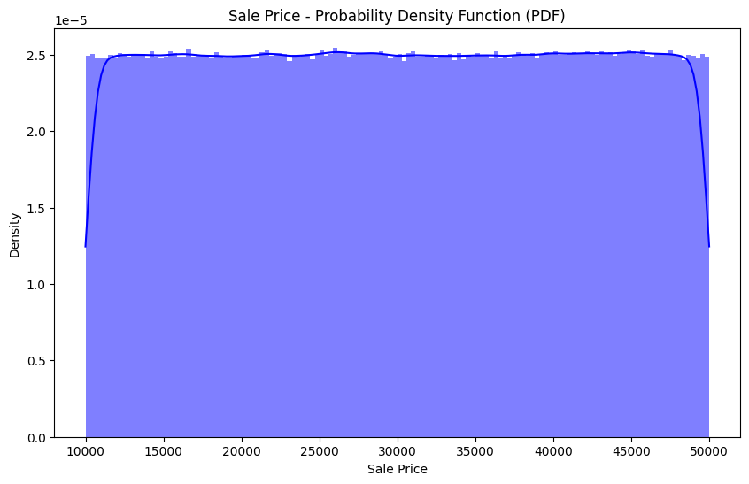

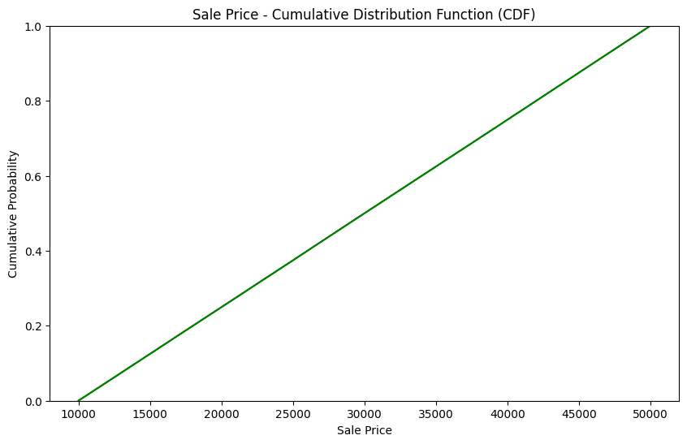

```python
feature = 'Sale Price'

# PDF hesaplama ve histogram olarak çizme
plt.figure(figsize=(10, 6))
sns.histplot(data[feature], kde=True, stat="density", linewidth=0, color="blue")
plt.title(f'{feature} - Probability Density Function (PDF)')
plt.xlabel(feature)
plt.ylabel('Density')
plt.show()

# CDF hesaplama ve histogram olarak çizme
plt.figure(figsize=(10, 6))
sns.ecdfplot(data[feature], color="green")
plt.title(f'{feature} - Cumulative Distribution Function (CDF)')
plt.xlabel(feature)
plt.ylabel('Cumulative Probability')
plt.show()
```

### Veri Dağılımı Yorumlaması

#### PDF

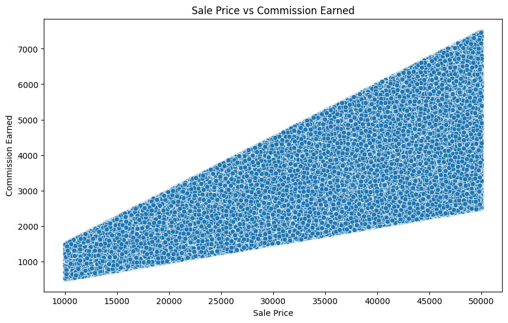

```python
# Scatter Plot: 'Sale Price' vs 'Commission Earned'
plt.figure(figsize=(10, 6))
sns.scatterplot(x='Sale Price', y='Commission Earned', data=data)
plt.title('Sale Price vs Commission Earned')
plt.xlabel('Sale Price')
plt.ylabel('Commission Earned')
plt.show()
```

### Scatter Plot:

Bu grafik, Sale Price ile Commission Earned arasındaki ilişkiyi gösterir. Eğer bu iki değişken arasında bir ilişki varsa, noktalar belirli bir eğilimde gruplanabilir. Bu grafik, aracın satış fiyatının komisyon miktarı ile nasıl ilişkili olduğunu anlamamıza yardımcı olur. Örneğin, yüksek satış fiyatlarına sahip araçların daha yüksek komisyonlar getirmesi beklenebilir.

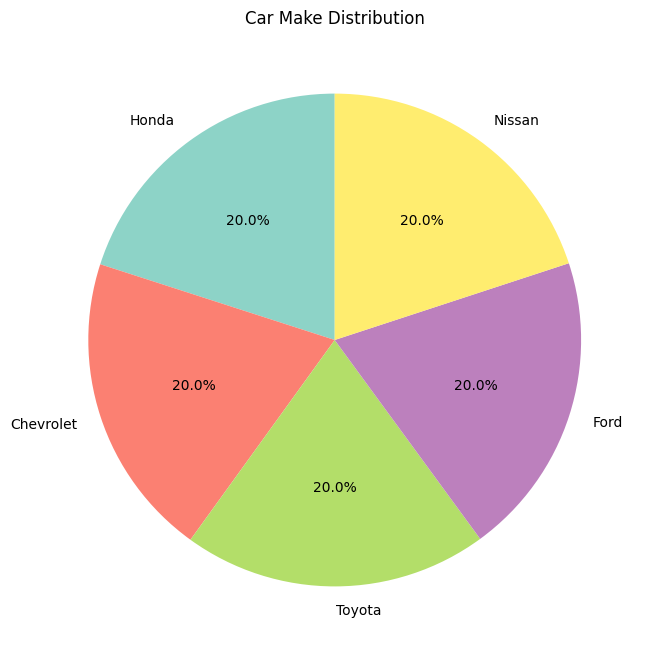

```python
# Pie Chart: 'Car Make' dağılımı
car_make_counts = data['Car Make'].value_counts()
plt.figure(figsize=(8, 8))
car_make_counts.plot.pie(autopct='%1.1f%%', startangle=90, cmap='Set3')
plt.title('Car Make Distribution')
plt.ylabel('')
plt.show()
```

### Pie Chart:

Bu grafik, her bir Car Make türünün verilerdeki oranını gösterir. Verilerin hangi araba markasında yoğunlaştığını anlamamıza yardımcı olur. Örneğin, en çok satılan araba markalarının yüzdesini görsel olarak belirleyebiliriz.

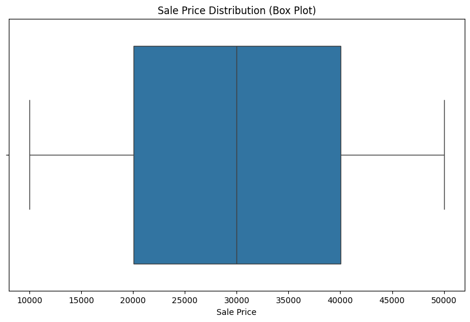

```python
# Box Plot: 'Sale Price' dağılımı
plt.figure(figsize=(10, 6))
sns.boxplot(x=data['Sale Price'])
plt.title('Sale Price Distribution (Box Plot)')
plt.xlabel('Sale Price')
plt.show()
```

### Box Plot:

Bu grafik, Sale Price sütunundaki fiyat dağılımını görselleştirir. Kutu, veri setindeki merkezi eğilimi (ortanca) ve verinin yayılımını (çeyrekler arası mesafe) gösterir. Aynı zamanda, uç noktalarda (outliers) herhangi bir anormal değer olup olmadığını da gözlemleyebiliriz.

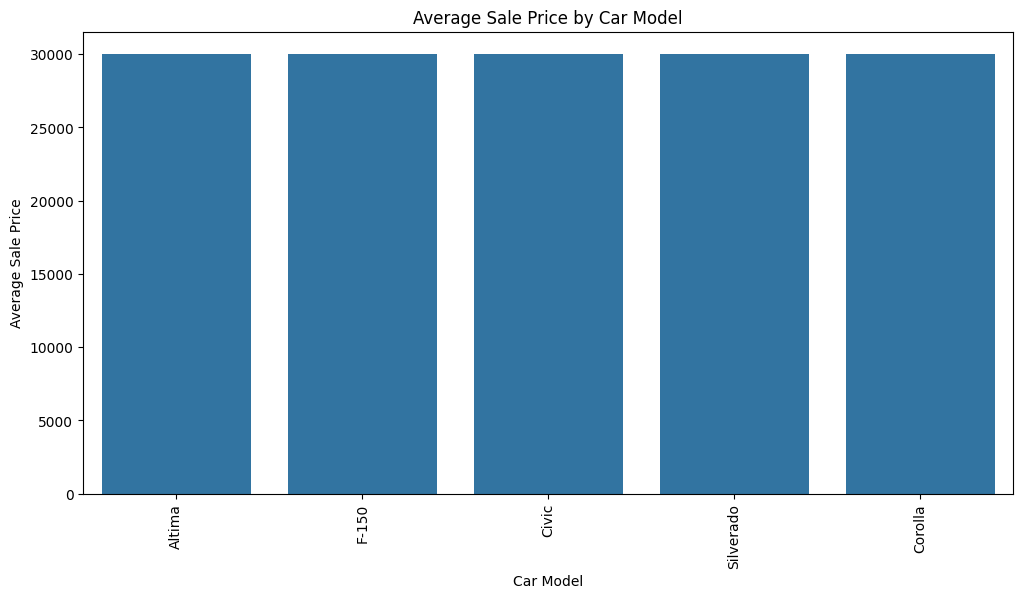

```python
# Bar Plot: 'Car Model' ve 'Sale Price' ortalama
plt.figure(figsize=(12, 6))
sns.barplot(x='Car Model', y='Sale Price', data=data, estimator=np.mean, errorbar=None)
plt.title('Average Sale Price by Car Model')
plt.xlabel('Car Model')
plt.ylabel('Average Sale Price')
plt.xticks(rotation=90)
plt.show()
```

### Bar Plot:

Bu grafik, farklı Car Model'lerin ortalama satış fiyatlarını karşılaştırır. Modeller arasındaki fiyat farklarını görselleştirir ve hangi araç modelinin daha pahalı olduğunu anlamamıza yardımcı olur. Bu tür bir plot, her bir modelin pazarda nasıl konumlandığını anlamak için yararlıdır.

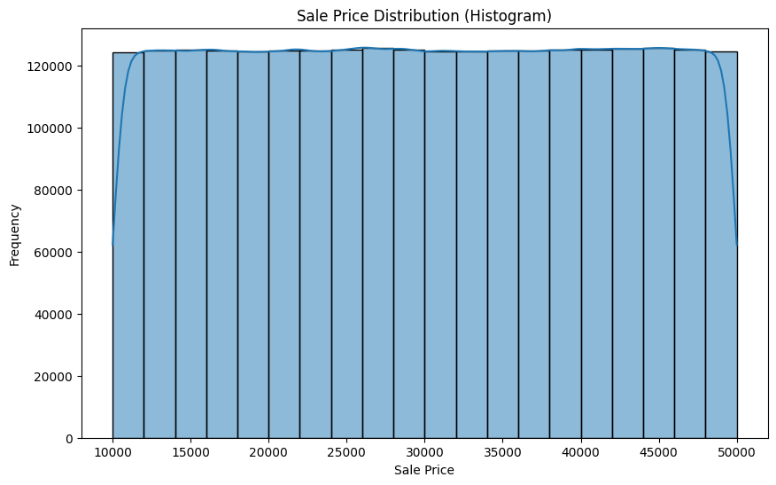

```python
# Histogram: 'Sale Price' dağılımı
plt.figure(figsize=(10, 6))
sns.histplot(data['Sale Price'], bins=20, kde=True)
plt.title('Sale Price Distribution (Histogram)')
plt.xlabel('Sale Price')
plt.ylabel('Frequency')
plt.show()
```

### Histogram:

Sale Price sütunundaki fiyatların sıklık dağılımını gösterir. Bu grafik, fiyatların hangi aralıkta yoğunlaştığını ve fiyatların nasıl dağıldığını görselleştirir. Ayrıca, KDE (Kernel Density Estimation) çizgisiyle, fiyat dağılımının daha pürüzsüz bir gösterimi sağlanır.

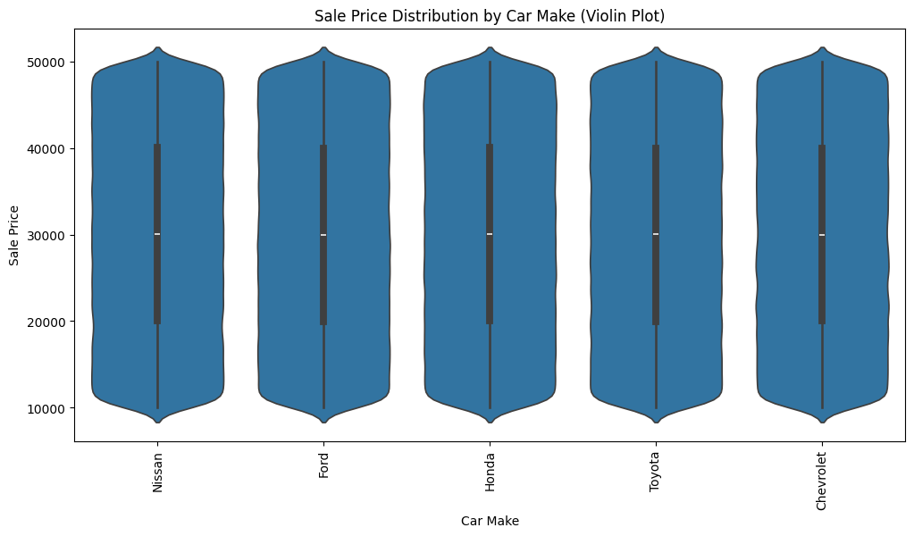

```python
# Violin Plot: 'Car Make' ve 'Sale Price' dağılımı
plt.figure(figsize=(12, 6))
sns.violinplot(x='Car Make', y='Sale Price', data=data)
plt.title('Sale Price Distribution by Car Make (Violin Plot)')
plt.xlabel('Car Make')
plt.ylabel('Sale Price')
plt.xticks(rotation=90)
plt.show()
```

### Violin Plot:

Car Make ve Sale Price arasındaki dağılımı görselleştirir. Bu grafik, her marka için satış fiyatlarının yoğunlaştığı aralıkları ve dağılımın şekli hakkında bilgi verir. Ayrıca, uç noktalar (outliers) ve medyan değerlerin yanı sıra dağılımın genişliğini de gözlemleyebiliriz.

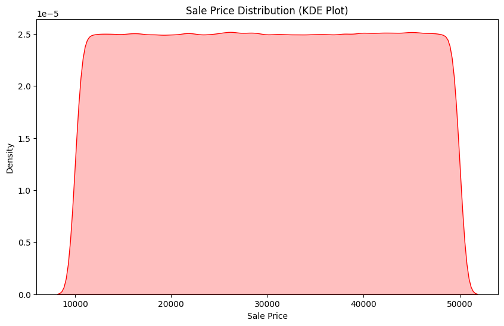

```python
# KDE Plot: 'Sale Price' dağılımı
plt.figure(figsize=(10, 6))
sns.kdeplot(data['Sale Price'], fill=True, color="r")
plt.title('Sale Price Distribution (KDE Plot)')
plt.xlabel('Sale Price')
plt.ylabel('Density')
plt.show()
```

### KDE Plot:

Kernel Density Estimation (KDE) ile, Sale Price sütununun olasılık yoğunluğunu görselleştiririz. Bu grafik, fiyatların hangi aralıklarda daha yoğun olduğunu pürüzsüz bir şekilde gösterir ve histogramdan farklı olarak, verinin daha doğru bir dağılımını sunar.

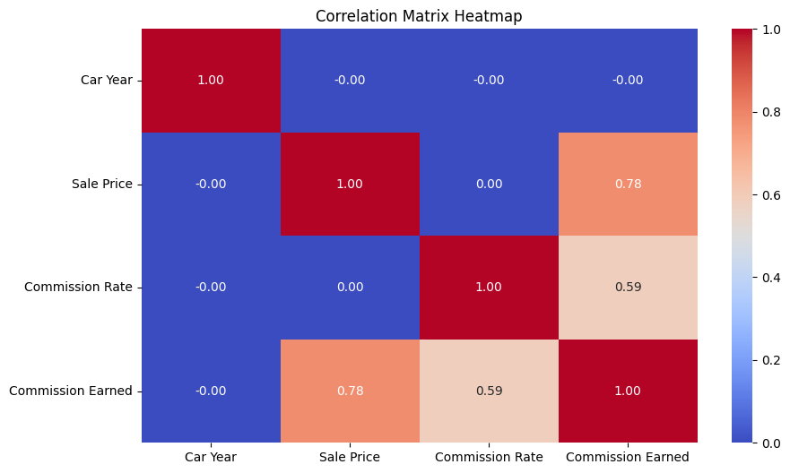

```python
numerical_data = data.select_dtypes(include=[np.number])

# Korelasyon matrisini hesapla
correlation_matrix = numerical_data.corr()


plt.figure(figsize=(10, 6))
sns.heatmap(correlation_matrix, annot=True, cmap='coolwarm', fmt='.2f', cbar=True)
plt.title('Correlation Matrix Heatmap')
plt.show()
```

### Heatmap:

Bu grafik, veri setindeki sayısal sütunlar arasındaki korelasyonları görselleştirir. Korelasyon değeri, iki değişken arasındaki ilişkinin gücünü gösterir. Eğer korelasyon değeri 1'e yakınsa, iki değişken güçlü bir şekilde birbirine bağlıdır. -1'e yakınsa, ters yönde bir ilişki vardır. 0 ise, iki değişken arasında hiçbir ilişki olmadığını belirtir.